# Analyse Exploratoire

ouverture de donnees_pays, on labelise les lignes avec le code iso du pays

```r
donnees_pays = read.csv('3.donnees_propres/donnees_pays.csv')
rownames(donnees_pays) = donnees_pays$ISO3
```

# Exploration des pays cibles

## Population 1 : le monde entier

On distingue les variables utilisées pour le calcul et celles utilisées pour illustrer.

On utilise toutes les variables quantitatives sauf le prix de production du poulet (46% de valeurs nulles)

```r
# Variables quantitatives utilisées :
pop1.var.quant = c(
  'disp_alim_general__kcal_hab_jr',
  'disp_prot_general__g_hab_jr',
  'disp_alim_volaille__kcal_hab_jr',
  'pib_hab_13',
  'indice_risque',
  'indice_affaire',
  'distance_fr__km',
  'pop_13',
  'pop_evol_5a_pt',
  'disp_prot_anim__pt',
  'import_volaille__kg_hab_an',
  'prod_volaille__kg_hab_an'
)

# Variables illustratives :
pop1.var.quant.supp = c()
pop1.var.qual.supp = c()
```

### Clustering ascendant hiérarchique

#### Préparation des données

```r
pop1.cah = donnees_pays[,pop1.var.quant]
pop1.cah = scale(pop1.cah) # on normalise les données
```

#### Calcul

```r
pop1.cah.result = hclust(dist(pop1.cah))
```

#### Dendrogramme

```r
png(file="5.resultats/dendrogramme.png",width=1800,height=750)
par(cex=0.8, mar=c(5, 8, 4, 1))
plot(pop1.cah.result, xlab="", ylab="", main="", hang = -1)
par(cex=2)
title(xlab="Pays", ylab="Distance", main="")
dev.off()
```

**Le Dendrogramme est exporté sous forme d’image**

Selection à 5 groupes

```r
pop1.cah.groupes = factor(cutree(pop1.cah.result, 5))
```

```r
write.csv2(pop1.cah.groupes, file = '5.resultats/groupe_pays.csv', col.names=NA)
```

#### calcul des centroïdes

```r
centroides = data.frame() # je créé un df vide

# pour chaque groupes,
nom_groupes = unique(pop1.cah.groupes)
for (i in nom_groupes) {
  # je recupere les valeurs du cluster
  groupe = subset(pop1.cah, pop1.cah.groupes == i)
  # je calcule le centroide en faisant une moyenne par colonne
  centroid = colMeans(groupe, na.rm = TRUE)
  # je l'ajoute au df
  centroides = rbind(centroides, centroid)
}

# je renomme chaque colonne avec le nom du dernier centroide calculé
names(centroides) = names(centroid)
rownames(centroides) = nom_groupes
```

On va determiner le pays qui est le plus proche de chaque centroide

```r
# on calcule la distance entre chaque pays et chaque centroides
dist_cent_pays = dist(rbind(pop1.cah, centroides))
# on convertie l'objet dist en matrice
dist_cent_pays = as.matrix(dist_cent_pays)
# on restreind
dist_cent_pays = dist_cent_pays[as.character(nom_groupes),
                                row.names(donnees_pays)]
```

on renomme les centroides avec leur numero et le pays le plus proche

```r
nv_noms_groupes = c()
for (nom in nom_groupes) {
  pays = names(which.min(dist_cent_pays[nom,]))
  nv_nom =  paste(nom, ' (', pays, ')', sep = '')
  nv_noms_groupes = c(nv_noms_groupes, nv_nom)
}
rownames(centroides) = nv_noms_groupes
```

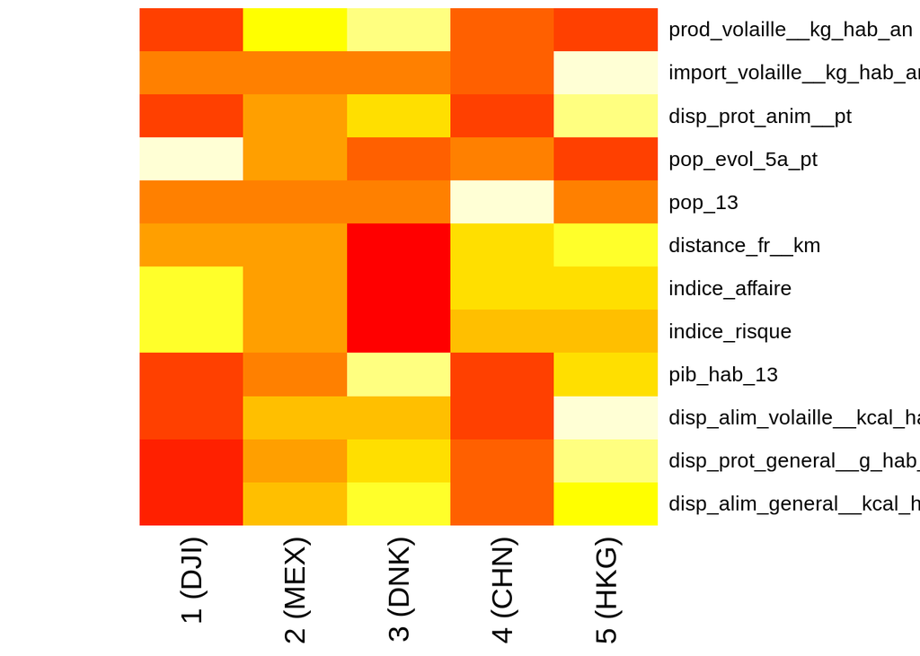

```r
heatmap(t(as.matrix(centroides)), Rowv = NA, Colv = NA, margins = c(6,6))
```

```r
write.csv2(centroides, file = '5.resultats/centroides.csv')
```

### ACP

On définie les variables utilisées et l’indice des variables des supplémentaires

```r
# toute les variables utilisées
pop1.var.all = c(pop1.var.quant, pop1.var.quant.supp, pop1.var.qual.supp)
# l'indice des variables supplémentaires
pop1.var.qual.supp.indice = which(pop1.var.all %in% pop1.var.qual.supp)
pop1.var.quant.supp.indice = which(pop1.var.all %in% pop1.var.quant.supp)
```

```r
pop1.pca.result = PCA(donnees_pays[,pop1.var.all],
                      quanti.sup = if(length(pop1.var.quant.supp.indice) == 0) NULL else pop1.var.quant.supp.indice,
                      quali.sup  = if(length(pop1.var.qual.supp.indice) == 0) NULL else pop1.var.qual.supp.indice,
                      graph = FALSE)
pop1.pca.result.var = get_pca_var(pop1.pca.result)
```

#### Visualisation de l’ACP

##### Eboulis des valeurs propres

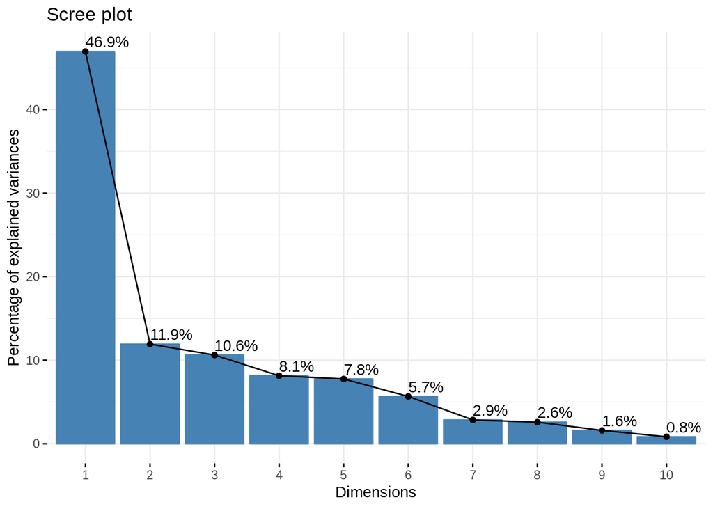

```r
fviz_eig(pop1.pca.result, addlabels = TRUE)
```

##### qualité de la représentation

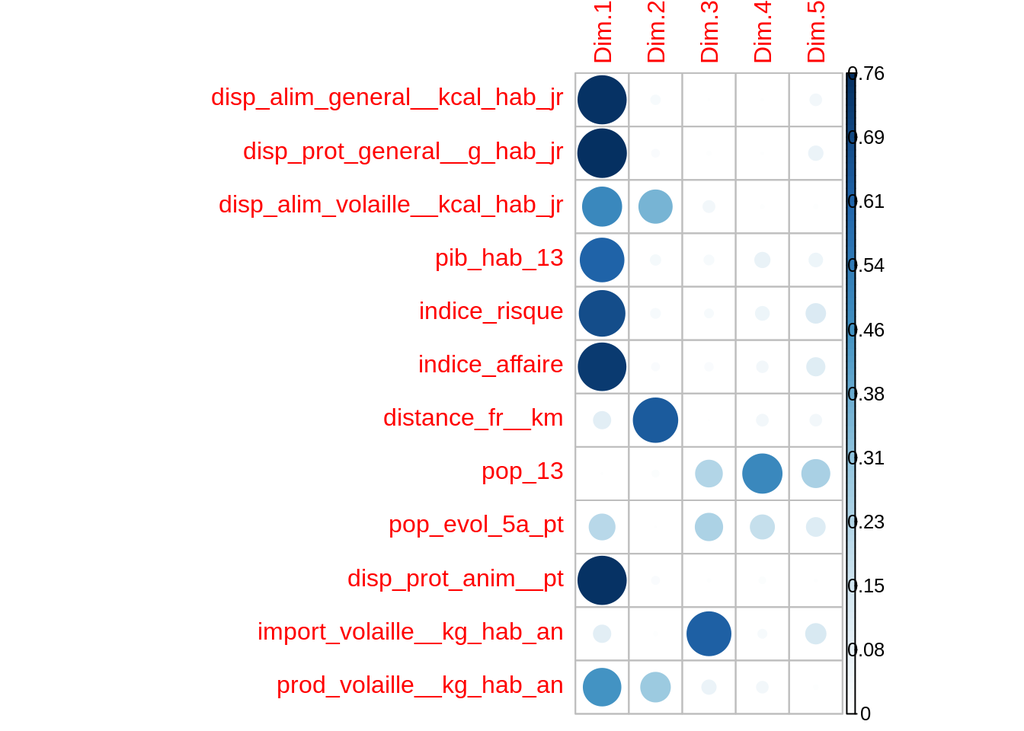

```r
corrplot(pop1.pca.result.var$cos2, is.corr=FALSE)
```

##### cercle des corrélations

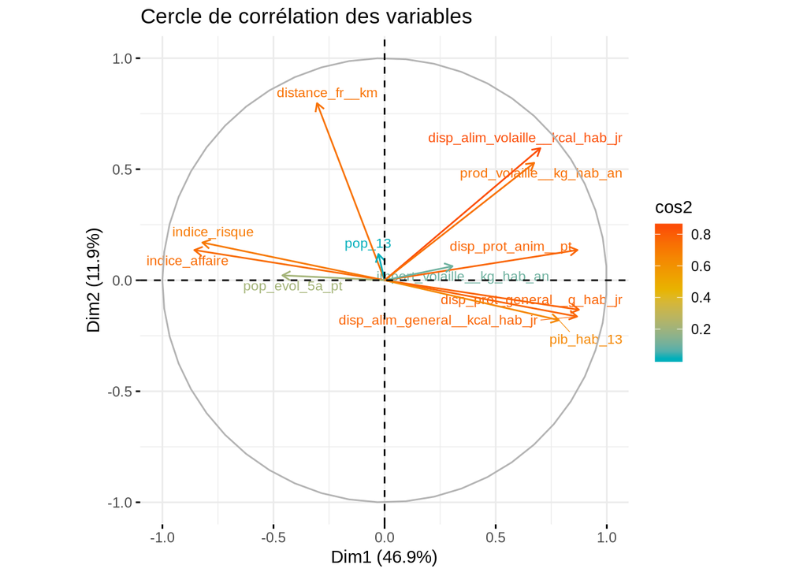

```r
fviz_pca_var(pop1.pca.result,
             title='Cercle de corrélation des variables',
             col.var = "cos2",
             gradient.cols =  c("#00AFBB", "#E7B800", "#FC4E07"),
             geom=c('arrow', 'text'), # point
             labelsize = 3,
             repel = TRUE
)
```

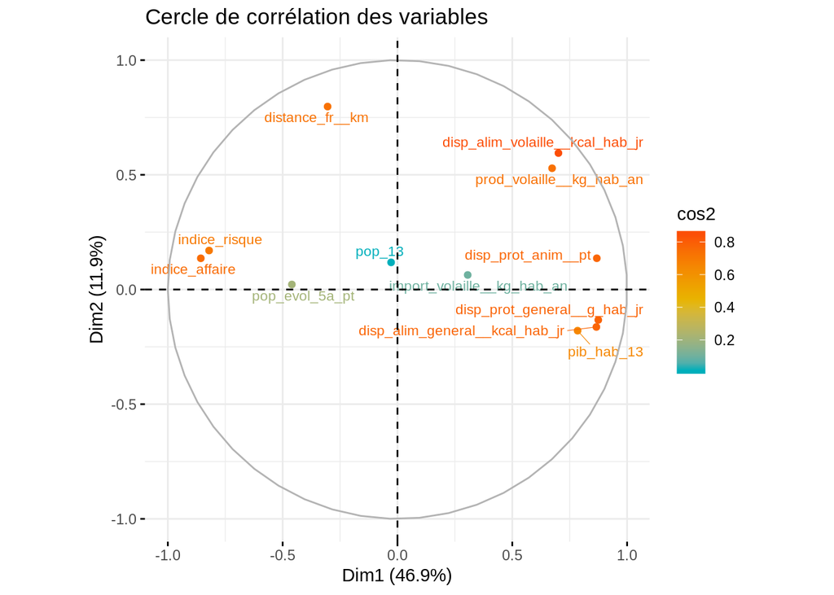

```r
fviz_pca_var(pop1.pca.result,
             title='Cercle de corrélation des variables',
             col.var = "cos2",

             gradient.cols =  c("#00AFBB", "#E7B800", "#FC4E07"),
             geom=c('point', 'text'), # point
             labelsize = 3,
             repel = TRUE
)
```

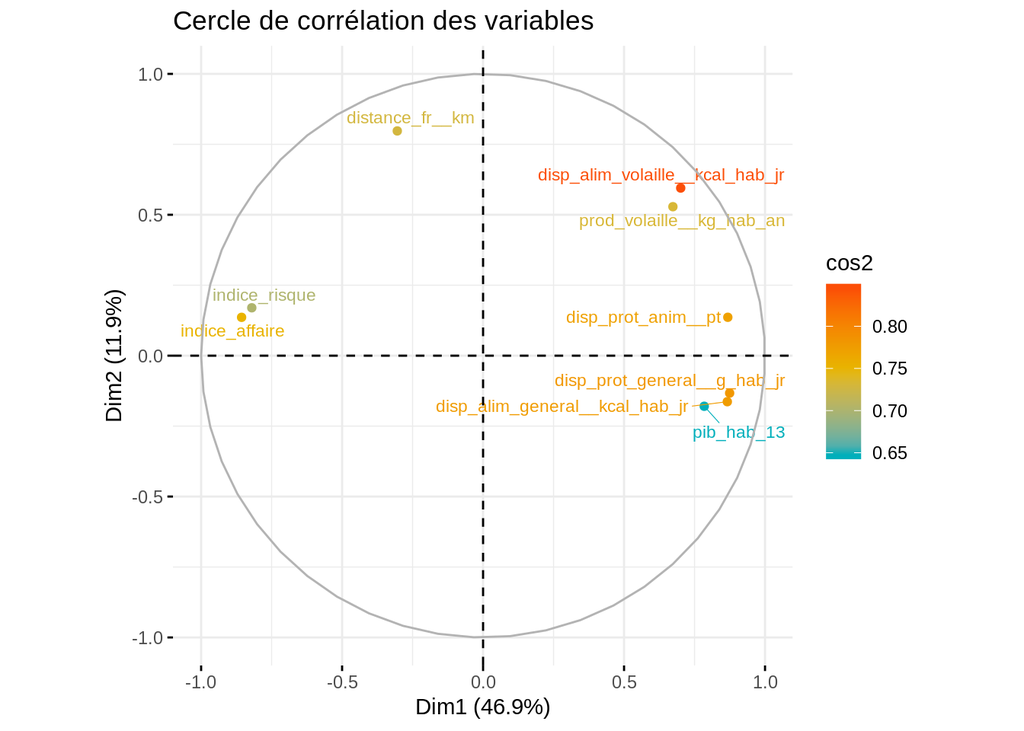

```r
fviz_pca_var(pop1.pca.result,
             title='Cercle de corrélation des variables',
             col.var = "cos2",
             select.var=list(cos2 = 0.5),
             gradient.cols =  c("#00AFBB", "#E7B800", "#FC4E07"),
             geom=c('point', 'text'), # point
             labelsize = 3,
             repel = TRUE
)
```

##### nuages des individus

On génère la figure

```r
figure = fviz_pca_ind(pop1.pca.result,
             geom=c("text", 'point'),
             labelsize=4,
             habillage = pop1.cah.groupes,
             alpha.ind="cos2",
             addEllipses=TRUE,
             repel = TRUE,
             mean.point = FALSE
)

# on l'enregistre

tiff("5.resultats/pop1.acp.tiff", units="in", width=16, height=10, res=300)
print(figure)
```

```
## Too few points to calculate an ellipse
## Too few points to calculate an ellipse
```

```r
dev.off() # Close the pdf device
```

```
## Too few points to calculate an ellipse
## Too few points to calculate an ellipse
```

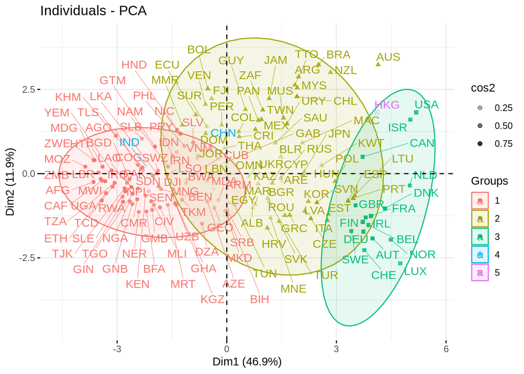

```r
figure
```

## Population 2 : Restriction aux pays plus proche de la france

On détermine le groupe auquel la France appartient

```r
groupe = pop1.cah.groupes['FRA']
```

On distingue les variables utilisées pour le calcul et celles utilisées pour illustrer.

```r
# quantité de valeurs nulles par variables
prct_val_na = round(sort(colMeans(is.na(donnees_pays[pop1.cah.groupes == groupe,])), decreasing = TRUE) * 100)
prct_val_na[prct_val_na != 0]
```

```
## prix_prod_poulet__usd_tonne
##                          19
```

```r
pop2.var.quant = c(
  'prix_prod_poulet__usd_tonne',
  'import_volaille__kg_hab_an',
  'prod_volaille__kg_hab_an',

  'pib_hab_13',
  'indice_risque'
)

pop2.var.quant.supp = c('pop_13', 'distance_fr__km')
pop2.var.qual.supp = c('membre_eee')
```

### ACP

On définie les variables utilisées et l’indice des variables des supplémentaires

```r
# toute les variables utilisées
pop2.var.all = c(pop2.var.quant, pop2.var.quant.supp, pop2.var.qual.supp)
# l'indice des variables qualitatives supplémentaires
pop2.var.qual.supp.indice = which(pop2.var.all %in% pop2.var.qual.supp)
pop2.var.quant.supp.indice = which(pop2.var.all %in% pop2.var.quant.supp)
```

On définie le dataframe, et l’on renomme chaque ligne pour ajouter des informations

```r
pop2.pca = donnees_pays[pop1.cah.groupes == groupe,
                        pop2.var.all]
rownames(pop2.pca) = paste(
  rownames(pop2.pca), ' ',
  round(pop2.pca$pop_13 / 1e6), 'm ',
  round(pop2.pca$distance_fr__km), 'km',
  sep='')
```

```r
pop2.pca.result = PCA(
  X = pop2.pca,
  quanti.sup = if(length(pop2.var.quant.supp.indice) == 0) NULL else pop2.var.quant.supp.indice,
  quali.sup  = if(length(pop2.var.qual.supp.indice) == 0) NULL else pop2.var.qual.supp.indice,
  graph = FALSE
  )
pop2.pca.result.var = get_pca_var(pop2.pca.result)
```

#### Visualisation de l’ACP

##### éboulis des valeurs propres

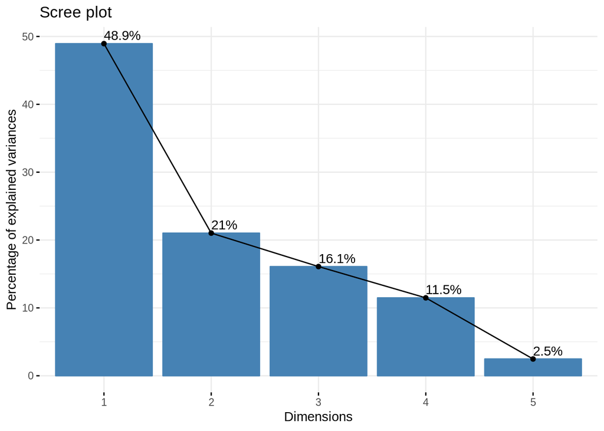

```r
fviz_eig(pop2.pca.result, addlabels = TRUE)
```

##### qualité de la représentation

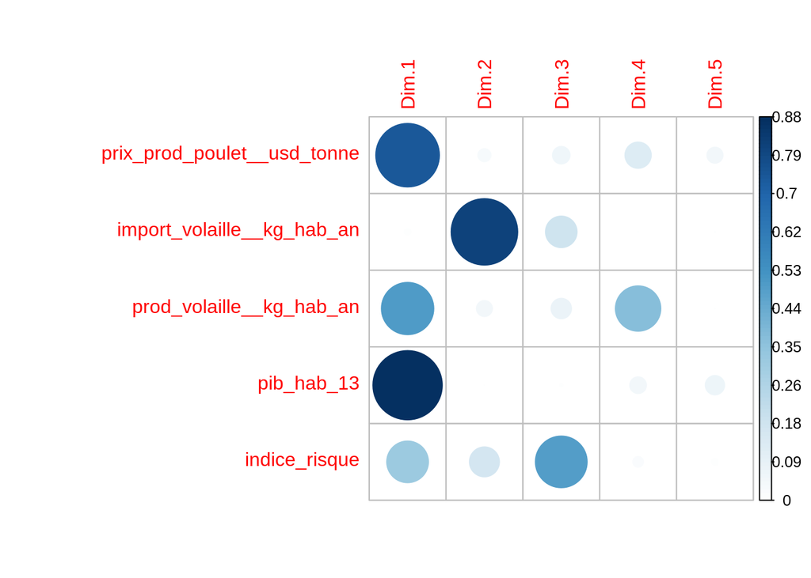

```r
corrplot(pop2.pca.result.var$cos2, is.corr=FALSE)
```

##### cercle des corrélations

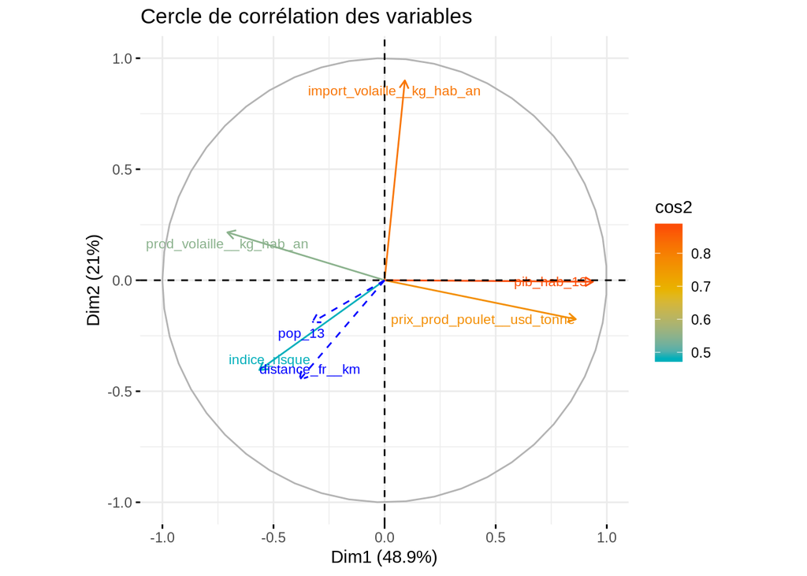

```r
fviz_pca_var(pop2.pca.result,
             title='Cercle de corrélation des variables',
             col.var = "cos2",
             gradient.cols =  c("#00AFBB", "#E7B800", "#FC4E07"),
             #alpha.var = "cos2",
             geom=c('arrow', 'text'),
             labelsize = 3,
             repel = TRUE
)
```

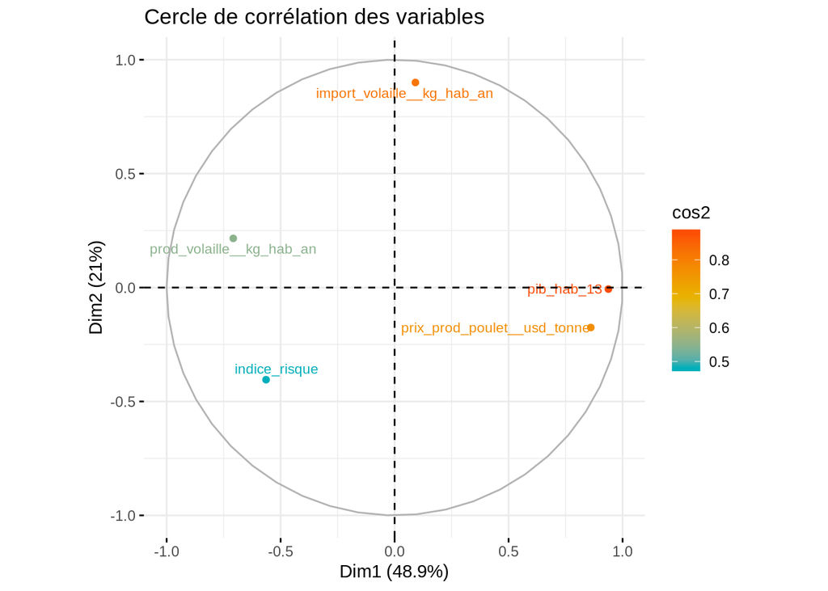

```r
fviz_pca_var(pop2.pca.result,
             title='Cercle de corrélation des variables',
             col.var = "cos2",
             invisible='quanti.sup',
             gradient.cols =  c("#00AFBB", "#E7B800", "#FC4E07"),
             #alpha.var = "cos2",
             geom=c('point', 'text'),
             labelsize = 3,
             repel = TRUE
)
```

##### nuages des individus

```r
# on créé la figure
figure = fviz_pca_ind(pop2.pca.result,
             geom=c("text", 'point'),
             habillage = if(length(pop2.var.qual.supp.indice) == 0) 'none' else pop2.var.qual.supp.indice,
             labelsize=3,
             alpha.ind="cos2",
             #pointsize='5',
             repel = TRUE,
             mean.point = FALSE
)

# On l'enregistre
tiff("5.resultats/pop2.acp.tiff", units="in", width=8, height=5, res=300)
print(figure)
dev.off() # Close the pdf device
```

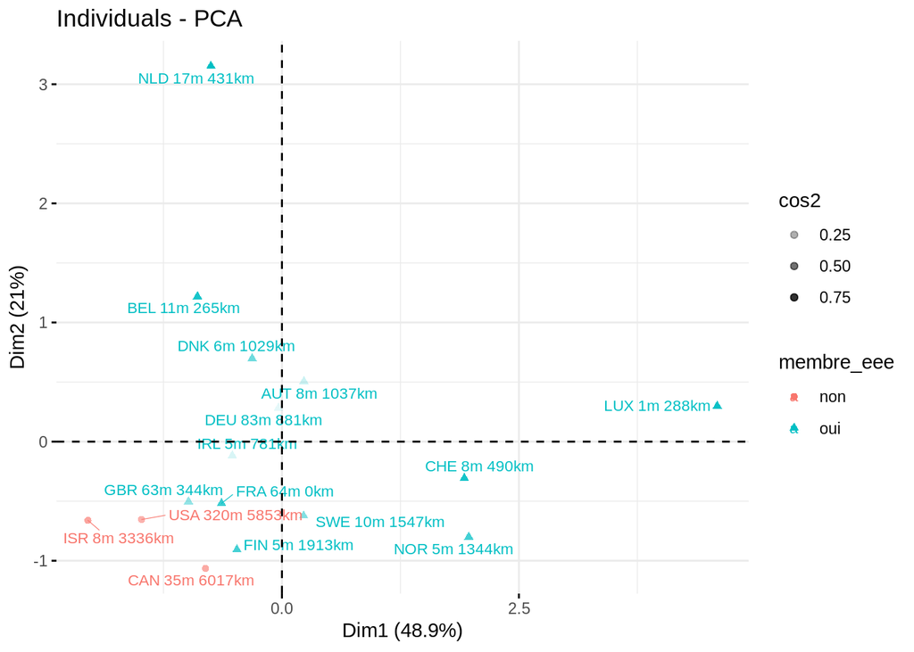

```r
# on l'affiche
figure
```

## Conclusion

Les pays intéressants :

- Allemagne
- Pays Bas
- Luxembourg
- Suisse

# Tests statistiques

## Test d’adéquation à la loi normale

```r
echantillon = donnees_pays$disp_alim_general__kcal_hab_jr
```

On plot

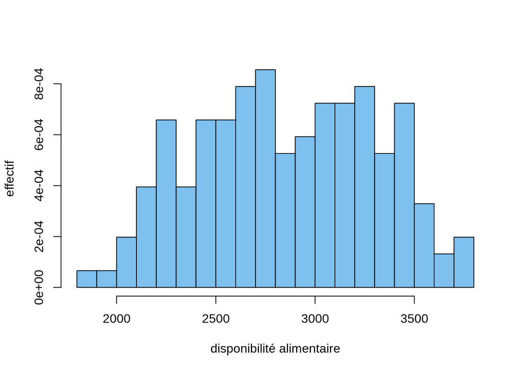

```r
h <- hist(echantillon, breaks = 20, col = "skyblue2", xlab = 'disponibilité alimentaire', ylab = 'effectif', main = '', freq = FALSE)

x_norm = seq(min(echantillon), max(echantillon), length = 40)
y_norm = dnorm(x_norm,mean(echantillon),sd(echantillon))

y_norm <- y_norm * diff(h$mids[1:2]) * length(echantillon)

lines(x_norm, y_norm, col = "red", lwd=2)
```

Hypothèse nulle : l’échantillon suit une loi normale Alternative : l’échantillon ne suit pas une loi normale

Kolmogorov-Smirnoc car n > 60

```r
ks.test(echantillon,"pnorm",mean=mean(echantillon),sd=sd(echantillon))
```

```
##
##  One-sample Kolmogorov-Smirnov test
##
## data:  echantillon
## D = 0.061931, p-value = 0.6044
## alternative hypothesis: two-sided
```

On a 60% de chance de rejetter l’hypothèse nulle à tord.

*On a 60% de chance de se tromper si on affirme que l’échantillon ne suit pas une loi normale*

## On compare deux échantillons

Les pays du groupe 1 & du groupe 3

```r
echantillon1 = subset(donnees_pays, pop1.cah.groupes == 1)$disp_alim_general__kcal_hab_jr
echantillon2 = subset(donnees_pays, pop1.cah.groupes == 3)$disp_alim_general__kcal_hab_jr
```

```r
var.test(echantillon1, echantillon2) # egalité des variances
```

```
##
##  F test to compare two variances
##
## data:  echantillon1 and echantillon2
## F = 3.8705, num df = 70, denom df = 15, p-value = 0.005322
## alternative hypothesis: true ratio of variances is not equal to 1
## 95 percent confidence interval:
##  1.544216 7.848030
## sample estimates:
## ratio of variances
##           3.870495
```

p-val de 0.5%, on peut rejetter l’hypothèse d’égalité des variances.

Les lois ne sont donc pas les mêmes

```r
t.test(echantillon1, echantillon2) # egalité des moyenne
```

```
##
##  Welch Two Sample t-test
##
## data:  echantillon1 and echantillon2
## t = -17.021, df = 45.208, p-value < 2.2e-16
## alternative hypothesis: true difference in means is not equal to 0
## 95 percent confidence interval:
##  -1078.8607  -850.5741
## sample estimates:
## mean of x mean of y
##  2525.845  3490.562
```